# Betsy Pleasants, DrPH(c) MPH

## [she/her/hers](https://www.aclunc.org/article/frequently-asked-questions-whats-pronoun)

## [Society for Family Planning](https://www.societyfp.org/), Emerging Scholar 2022

## UC Berkeley School of Public Health

## Doctoral Candidate, [DrPH program](https://publichealth.berkeley.edu/academics/interdisciplinary/doctor-of-public-health-drph/)

## Graduate Student Researcher, [Wallace Center for MCAH Research](https://www.wallacecenter.berkeley.edu/) and [Bixby Center for Population, Health and Sustainability](https://bixby.berkeley.edu/)

## [Personal website](https://www.bpleasants.com/)

### I am a public health practitioner and researcher invested in exploring and addressing sexual and reproductive health inequities collaboratively and creatively.

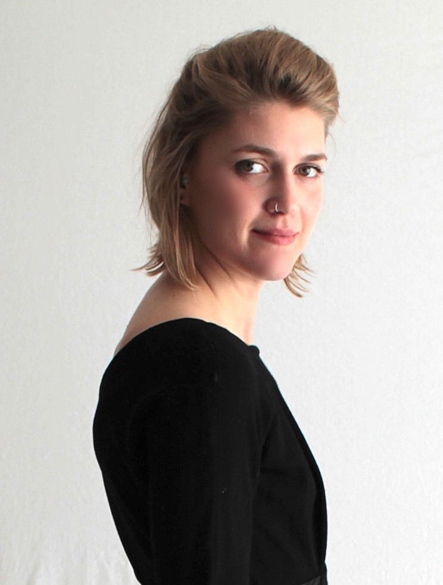

###### **About:**

Elizabeth (Betsy) Pleasants is a Doctoral Candidate in the Doctor of Public Health Program (DrPH) in UC Berkeley’s School of Public Health. She was born and raised in North Carolina but now lives in Oakland, California. She received her Master’s in Public Health in the Maternal, Child, and Adolescent Health (MCAH) program at UC Berkeley in Spring of 2019. She has experience working with various groups on public health research and programs related to contraception, abortion, HIV prevention, perinatal care, health equity, access to information, and healthcare policy. She currently works with the Fung Fellowship at UC Berkeley; the Wallace Center for MCAH Research; the Bixby Center for Population, Health and Sustainability; and Ibis Reproductive Health. She has interest in mixed methods approaches to researching and intervening upon sexual and reproductive health issues, particularly in access to family planning information and services.

Her dissertation research, Understanding r/abortion: A mixed-methods study of an online health community for abortion, will explore community members’ use of an abortion subreddit in 2022, in consideration of the changing landscape of abortion access and technology use in the United States. This project will combine the analytic efficiency of computational linguistics with the nuanced understandings emerging from hybrid thematic qualitative analysis to explore how this community is used pre and post Roe, overall and with a specific interest in barriers to abortion access and strategies for overcoming those barriers. This work will provide real-time insights into the abortion experiences, concerns, needs, and outcomes of people who may never make it to clinical abortion care.

## [Projects](https://bpleasants.github.io/projects)